# hunterdickey_A4

Hunter Dickey

10/14/2021

Minimum Result Analysis: Race “Is there disproportionate education attainment by race in San Mateo County?”

For the population 25 years and older in San Mateo county, there is a noticeable disproportionality to educational attainment. When compared to the share of total race groups by populations, the white racial group is underrepresented (at 38%) by 14% at the “less-than diploma level” when when juxtaposed with their 52% share of the population. Across the other education levels of ‘high school graduate’, ‘some college’, and ‘bachelor’s degree or higher’, the white proportions are 50%, 54%, and 55% respectively, which is far closer to the 52% of their total population proportion.

Similarly to the white population, Asian Americans are underrepresented in the ‘no diploma’, and ‘diploma only’ categories, while being much closer to their true population proportion, and slightly over represented in the ‘some college’ and ‘bachelor’s or higher’ catagories respectively.

On the flip side of this, American Indian and Alaska Native populations are noticeably over represented in the less than high school education level. American Indian and Alaska Natives make up 1.03% of this catagory’s population while their true percentage is .39% of the population at large.

Interestingly, the Black population proportion in San Mateo is underrepresented in the ‘less than high school’ category and over represented in the ‘high school graduate’ and ‘some college or associate’s degree’ levels. This is a positive trend I would infer, given America’s history with African Americans; however, Alaska Natives/American Indians and the ‘other’ race category are still underrepresented at large in the ‘college/higher education’ levels and Black Americans are still underrepresented at the ‘bachelor’s degree and beyond’ level.

Secondary Result Analysis: Ethnicity

The total San Mateo population proportion estimates are 13% Hispanic, and 26% White, and 61% other ethnicities. At the no diploma level, I found that the Hispanic population was severely over represented at 35%, the other ethnicities population was underrepresented by 4% and the white population was underrepresented at 7% of the population. At the diploma level, the Hispanic population was over represented by 7%, the white population was underrepresented by 5% and the other ethnicities category was underrepresented by 3%. Like in the race analysis the ‘college/associates degree’ level largely paralleled the general population smoothly while the bachelor level severely underrepresented the Hispanic community by 7%, while also over representing the white and other ethnicities populations by 6% and 2% respectively.

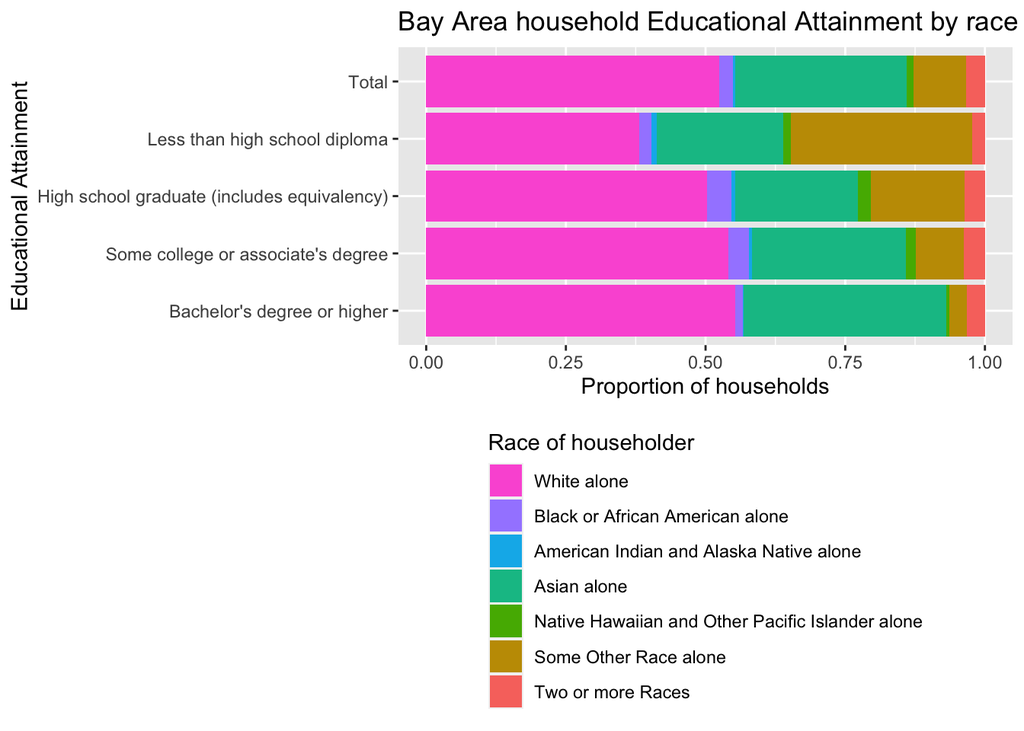

```
## [1] 48
```

```
## [1] 52
```

```
## [1] 0.3910827
```

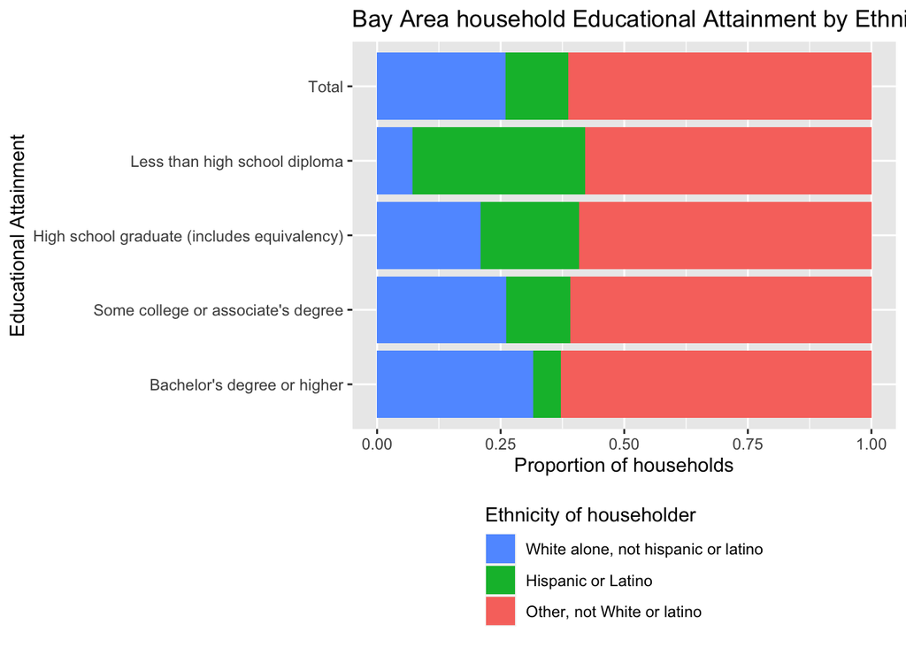

```
## # A tibble: 72 × 3
##    estimate education                                   race
##       <dbl> <chr>                                       <chr>
##  1     4006 Less than high school diploma               White alone, not hispan…
##  2    14110 High school graduate (includes equivalency) White alone, not hispan…
##  3    27128 Some college or associate's degree          White alone, not hispan…
##  4    71849 Bachelor's degree or higher                 White alone, not hispan…
##  5     3105 Less than high school diploma               White alone, not hispan…
##  6    14925 High school graduate (includes equivalency) White alone, not hispan…
##  7    29103 Some college or associate's degree          White alone, not hispan…
##  8    69263 Bachelor's degree or higher                 White alone, not hispan…
##  9    18088 Less than high school diploma               Hispanic or Latino
## 10    14771 High school graduate (includes equivalency) Hispanic or Latino
## # … with 62 more rows
```